# R Notebook

# Part 3: Drawing Conclusions from Data

## Chapter 9: The Confidence Game: Estimation

## Chapter 10: One-Sample Hypothesis Testing

### Z-testing in R (population variance is known)

IQ test:  
H0: mean IQ <= 100  
H1: mean IQ > 100

```r
IQ_data <- c(100, 101, 104, 109, 125, 116, 105, 108, 110)
mean_IQdata <- mean(IQ_data)
# IQ is known to have a SD of 15
popsd <- 15
# test if mean of sample is statistically different from the
# known IQ-mean of 100
mu <- 100
# Assume that alpha = 0.05
?pnorm
```

Because you use the z-score in the hypothesis test, the z-score here is called the **test statistic**.

```r
z.score <- round((mean(IQ_data) - mu)/
                     (popsd / sqrt(length(IQ_data))), 3)
z.score
```

```
[1] 1.733
```

```r
z.test <- function(x, mu, popsd) {
    one.tail <- NULL
    z.score <- round((mean(x) - mu)/(popsd/sqrt(length(x))), 3)
    one.tail.p <- round(pnorm(abs(z.score), lower.tail = F), 3)
    cat(" z =", z.score, "\n",
        "one-tailed probability =", one.tail.p, "\n",
        "two-tailed probability =", 2*one.tail.p)
}

z.test(IQ_data, mu, popsd)
```

```
 z = 1.733
 one-tailed probability = 0.042
 two-tailed probability = 0.084
```

Same with tigerstats:

```
[1] 0.04154783
```

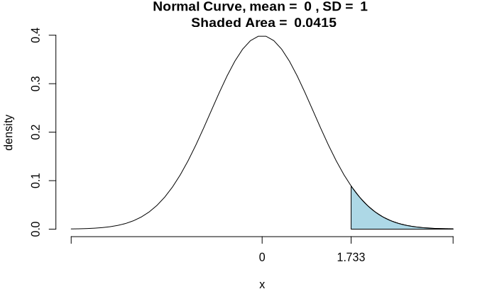

```r
tigerstats::pnormGC(
    bound = z.score,
    region = "above",
    mean = 0,
    sd = 1,
    graph = T
)
```

You set up a critical value, a decision criterion. The **critical value** is determined by alpha.

```r
qnorm(
    p = 0.95,
    lower.tail = T
)
```

```
[1] 1.644854
```

```
[1] 1.644854
```

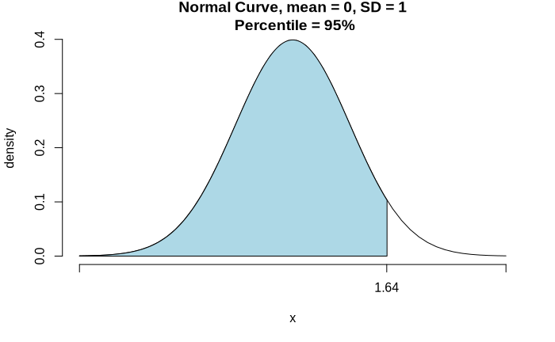

```r
tigerstats::qnormGC(
  area = 0.95,
  region = "below",
  mean = 0,
  sd = 1,
  graph = T
)
```

```r
qnorm(
    p = 0.95,
    mean = 100,
    sd = popsd/sqrt(length(IQ_data)),
    lower.tail = T
)
```

```
[1] 108.2243
```

With pnorm() only:

```r
pnorm(q = z.score,
      lower.tail = FALSE)
```

```
[1] 0.04154783
```

P-value is very low, this also suggests that H0 can be rejected.

Same using means and standard error instead of z-score:

```r
pnorm(
    q = mean_IQdata,
    mean = 100,
    sd = popsd/sqrt(length(IQ_data)),
    lower.tail = F
)
```

```
[1] 0.04151822
```

Show graphically using tigerstats:

```r
library(tigerstats)
?tigerstats::pnormGC
pnormGC(
    bound = z.score,
    region = "above",
    mean = 0,
    sd = 1,
    graph = T
)
```

[output not shown]

Tigerstats again, but using means instead of z-scores:

```
[1] 0.04151822
```

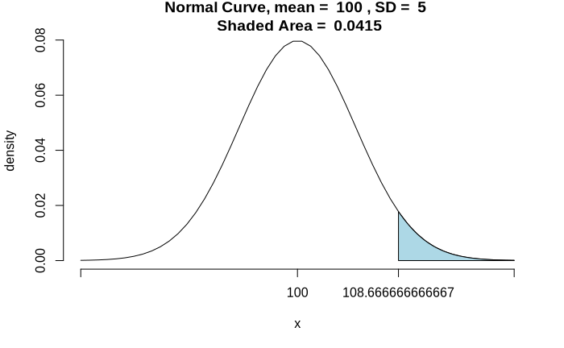

```r
pnormGC(
    bound = mean_IQdata,
    region = "above",
    mean = 100,
    sd = 15/sqrt(length(IQ_data)),
    graph = T
)
```

The **critical value** - the value of z that cuts off 5 percent of the area in a standard normal distribution - is 1.645:

```r
qnorm(p = 0.95)
```

```
[1] 1.644854
```

```
[1] 1.644854
```

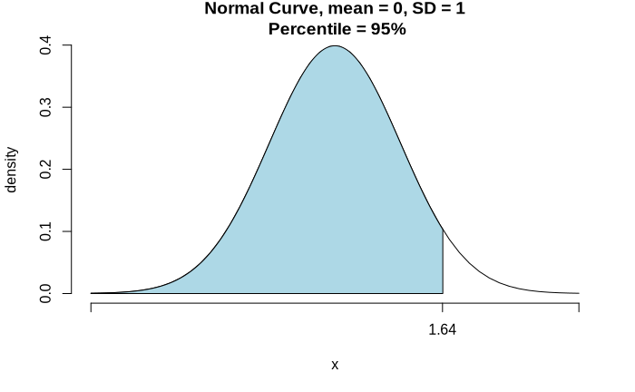

```r
tigerstats::qnormGC(area = 0.95, graph = TRUE)
```

In case of a two-tailed test the 5% is divided evenly between the left tail and the right tail.

```r
qnorm(p = 0.975)
```

```
[1] 1.959964
```

```
[1] 1.959964
```

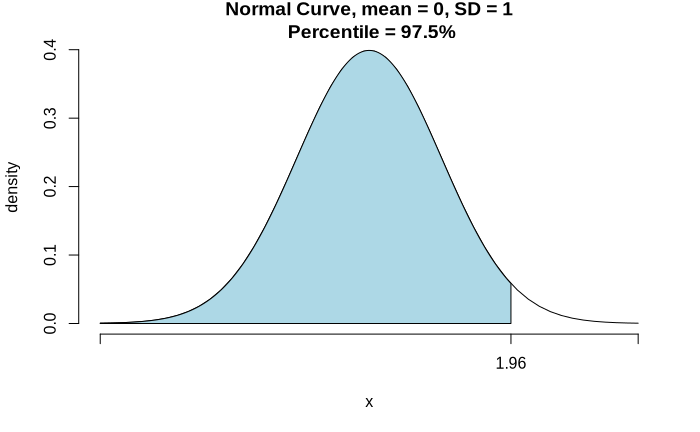

```r
qnormGC(area = 0.975, graph = TRUE)
```

### t for One

You usually have small samples. Usually you do NOT know the population parameters. Use ‘t’ as a **test statistic**.

### t-Testing in R

```r
FarKlempt_data <- c(3,6,9,9,4,10,6,4,12)
# ?t.test
mean(FarKlempt_data)
```

```
[1] 7
```

```r
sd(FarKlempt_data)
```

```
[1] 3.122499
```

Test if sample mean is greater than 4:

```r
t.test(FarKlempt_data,
       mu = 4,                      # H0 hypothesis
       alternative = "greater")
```

```
    One Sample t-test

data:  FarKlempt_data
t = 2.8823, df = 8, p-value = 0.01022
alternative hypothesis: true mean is greater than 4
95 percent confidence interval:
 5.064521      Inf
sample estimates:
mean of x
        7
```

Low p-value indicates that H0 can be rejected.

Manual t-value calculation against an assumed (H0) mean of 4:

```r
(mean(FarKlempt_data) - mean_H0) /
  (sd(FarKlempt_data) /
     sqrt(length(FarKlempt_data)))
```

```
[1] 2.882307
```

P-value is calculated as follows:

```r
pt(q = 2.8823,
   df = length(FarKlempt_data)-1,
   lower.tail = F)
```

```
[1] 0.01021962
```

### Working with t-Distributions

```r
round(dt(tValues, 12), 2)
```

```
[1] 0.00 0.01 0.06 0.23 0.39 0.23 0.06 0.01 0.00
```

```r
round(pt(tValues, 12), 2)
```

```
[1] 0.00 0.01 0.03 0.17 0.50 0.83 0.97 0.99 1.00
```

```r
qt(p = quartiles, df = 12)
```

```
[1]       -Inf -0.6954829  0.0000000  0.6954829        Inf
```

```r
round(rt(8, 12), 2)
```

```
[1] -0.50  0.25  0.20  1.99 -1.08  0.02  1.46  1.28
```

### Visualizing t-Distributions

Let’s visualize df=3, df=10 and a standard normal distribution:

```r
tValues <- seq(-4, 4, 0.1)
plot(
  x = tValues,
  y = dt(tValues, 3),   # density function with df=3
  type = "l",
  lty = "dotted",
  ylim = c(0, 0.4),
  xlab = "t",
  ylab = "f(t)"
)
lines(tValues,
      dt(tValues, 10),
      lty = "dashed")
```

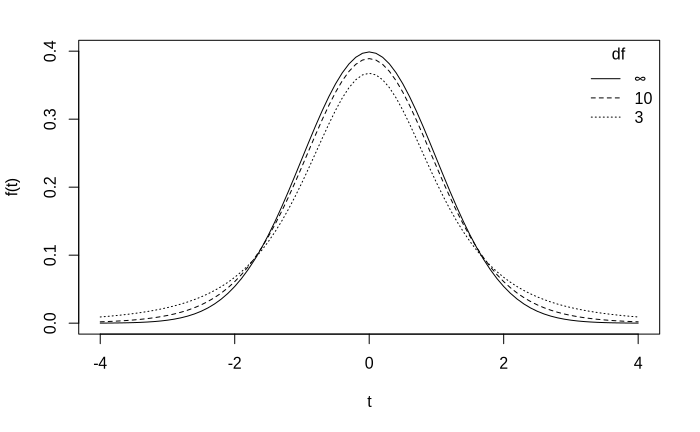

```r
lines(tValues,
      dnorm(tValues))
legend(
  "topright",
  title = "df",
  legend = c(expression(infinity), "10", "3"),
  lty = c("solid", "dashed", "dotted"),
  bty = "n"
)
```

## Chapter 11: Two-Sample Hypothesis Testing

### Z-testing for two samples in R

```r
oneTailProb
```

```
[1] 0.159
```

### t-Testing in R

```r
t.test(
  machine1,
  machine2,
  var.equal = TRUE,
  alternative = "two.sided",
  mu = 0
)
```

```
    Two Sample t-test

data:  machine1 and machine2
t = 2.4396, df = 18, p-value = 0.02528
alternative hypothesis: true difference in means is not equal to 0
95 percent confidence interval:
 0.4164695 5.5835305
sample estimates:
mean of x mean of y
       23        20
```

The t-value and the low p-value indicate that you can reject the null hypothesis. Machine 2 is significantly faster than Machine 1.

#### Working with a data frame and a formula

```r
with (
  FarKlempt.frame,
  t.test(
    prod.time ~ machine,
    var.equal = TRUE,
    alternative = "two.sided",
    mu = 0
  )
)
```

```
    Two Sample t-test

data:  prod.time by machine
t = 2.4396, df = 18, p-value = 0.02528
alternative hypothesis: true difference in means between group machine1 and group machine2 is not equal to 0
95 percent confidence interval:
 0.4164695 5.5835305
sample estimates:
mean in group machine1 mean in group machine2
                    23                     20
```

### Visualizing the results

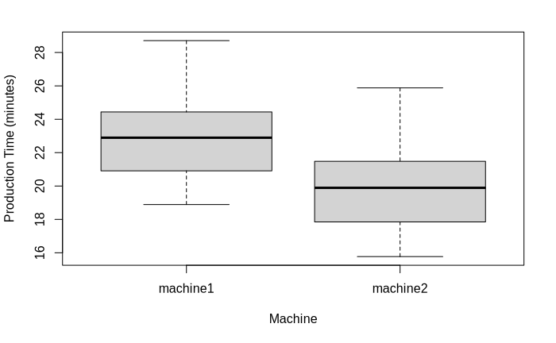

```r
with (
  FarKlempt.frame,
  boxplot(prod.time ~ machine, xlab =
            "Machine", ylab = "Production Time (minutes)")
)
```

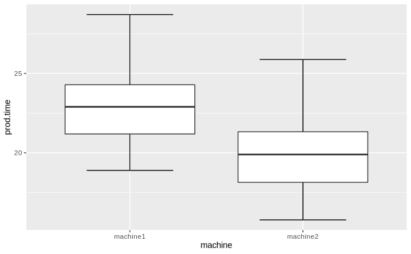

```r
ggplot(FarKlempt.frame, aes(x = machine, y = prod.time)) +
  stat_boxplot(geom = "errorbar", width = .5) +
  geom_boxplot()
```